# Simulating or predicting from a model plus logistic regression

Brendan Alexander

11/7/2019

# Simulation and Logistic reference from lab

These analyses use the abalone dataset as well as code that all of the lab groups worked on. To run the following code you’ll need the abalone dataset as well as the code that produced the datasets/models.

The code isn’t in this HTML (because it would look ugly), but it **is** in the .rmd file named “logistic_and_simulations.rmd” (should be on compass where you found this HTML file). To follow along with this analysis, just open the .rmd file and run all the code up to line 80. The text that you’re reading right now starts at line 82.

## Simulating from an lm() fit (with predictions as a pit stop)

There are 6 models in this .rmd file that I selected from models that the groups worked on. Please recall that the best model (based on AIC) was a multiple regression model of the form:

$$rings_i=\beta_0+\beta_1\cdot length_i+\beta_2\cdot diameter_i+\beta_3\cdot height_i+\beta_4\cdot whole_i+\beta_5\cdot mature_i +\epsilon_i$$
$$\epsilon_i \sim \mathcal{N}(0, \sigma^2)$$

```r
formula(model.fit)
```

```
## rings ~ length + diameter + height + whole + mature
```

where `rings` is discrete; `length`, `diameter`, `height`, and `whole` are continuous; and `mature` is categorical.

To simulate observations from this model we’ll need to extract the $\hat{\beta_i}$ (estimates of the $\beta$) as well as $\hat{\sigma}^2$ (the estimate of the varaince).

We’ll use the `summary()` function to access the coefficients of the model fit.

```r
summary(model.fit)
```

```
##
## Call:
## lm(formula = rings ~ length + diameter + height + whole + mature,
##     data = data2)
##
## Residuals:
##     Min      1Q  Median      3Q     Max
## -6.0651 -1.6100 -0.4873  0.8494 16.2995
##
## Coefficients:
##             Estimate Std. Error t value Pr(>|t|)
## (Intercept)   2.5515     0.3029   8.424  < 2e-16 ***
## length      -11.5266     2.0454  -5.635 1.86e-08 ***
## diameter     18.3895     2.5378   7.246 5.08e-13 ***
## height       42.3253     2.5242  16.768  < 2e-16 ***
## whole        -0.7085     0.2248  -3.152  0.00163 **
## matureM       0.9101     0.1023   8.895  < 2e-16 ***
## ---
## Signif. codes:  0 '***' 0.001 '**' 0.01 '*' 0.05 '.' 0.1 ' ' 1
##
## Residual standard error: 2.513 on 4169 degrees of freedom
## Multiple R-squared:  0.3935, Adjusted R-squared:  0.3928
## F-statistic:   541 on 5 and 4169 DF,  p-value: < 2.2e-16
```

We can extract the $\hat{\beta_i}$ by just reading them off the summary or by using the `coef()` function:

```r
coef(model.fit)
```

```
## (Intercept)      length    diameter      height       whole     matureM
##   2.5515305 -11.5266489  18.3895065  42.3253084  -0.7084529   0.9101479
```

We can extract the standard error of the residuals ($\hat{\sigma}$) using the `sigma()` function:

```r
sigma(model.fit)
```

```
## [1] 2.512925
```

This is the standard error, not the variance.

### Dummy variables

Note that `mature` is a categorical variable with two levels coded as “I”=infant, “M”=mature. To fit this in with linear regression, R (and any other program) will convert factor levels to dummy variables. The dummy variable coding here is simple enough: the reference level (“I”) is coded as 0, the non-reference level (“M”) is coded as 1. In this simple case with only 2 levels we only need 1 dummy variable column with 2 levels (0 and 1). In general, we need $k-1$ dummy variables when we have $k$ levels of a predictor.

For example, let’s say we had the original 3 levels (male, female, infant) and that infants were the reference level. Then we’d need 2 dummy variables (2 new columns). If we go in alphabetical order for male and femal, then we should have coding like this:

- Infant would be coded as: (0, 0)
- Female would be coded as: (1, 0)
- Male would be coded as : (0, 1)

Note that the dummy variable coding may be confusing if you have used “0” and “1” as the named factor levels. (Case in point: creating an inverse ROC curve). Dummy variable coding is based on which level is the reference level. The factor level could be “1”, or “99”, or “banana” but if you force it to be the reference level then the dummy coding is 0. The “mature” (factor level =“M”) has dummy variable equal to 1 in this example (and so “imature” is coded as 0).

### Predictions

The $\hat{y}_i$ are the predictions from the model. We calculate the $\hat{y}_i$ straight from the coeficients at some level of $x_i$ that we’re interested in.

For example, let’s say you wanted $\hat{y}_i$ for `length=0.545`, `diameter=0.4250`, `height=0.1400`, `whole=0.7995`, and `mature=1` (the abalone is mature, either male or female).

There are a few ways we can do this:

**Straight from the output**

```r
y1 <- 2.5515 + 0.545*(-11.5266) + 0.4250*(18.3895) + 0.1400*(42.3253) + 0.7995*(-0.7085) + 1*(0.9101)
y1
```

```
## [1] 10.35424
```

**Use the `predict()` function with the new data argument**

```r
#?predict.lm()

# new_x is just a data frame containing all the information on the points we want predictions for
# You have to include all variables that were in the model fit, and they must be in the same format
new_x <- data.frame(length=0.545,
                    diameter=0.4250,
                    height=0.1400,
                    whole=0.7995,
                    mature=as.factor("M"))
y2 <- predict(object = model.fit, newdata=new_x)
y2
```

```
##        1
## 10.35433
```

Looks like we have some rounding errors, but `y1` and `y2` are essentially the same value (`y1` probably has the rounding error since we just copied the output from the summary).

**Using linear algebra**

```r
# When using the linear algebra method make sure to include a leading '1' for the intercept coeficient
vec_x <- as.matrix(c(1, 0.545, 0.4250, 0.1400, 0.7995, 1))
b <- as.matrix(coef(model.fit),ncol=1)

y3 <- t(vec_x)%*%b
y3
```

```
##          [,1]
## [1,] 10.35433
```

What would the estimate be if we were talking about an immature abalone?

**Straight from the output**

```r
y4 <- 2.5515 + 0.545*(-11.5266) + 0.4250*(18.3895) + 0.1400*(42.3253) + 0.7995*(-0.7085) + 0*(0.9101)
y4
```

```
## [1] 9.444137
```

**Use the `predict()` function with the new data argument**

```r
#?predict.lm()

# new_x is just a data frame containing all the information on the points we want predictions for
# You have to include all variables that were in the model fit, and they must be in the same format
new_x <- data.frame(length=0.545,
                    diameter=0.4250,
                    height=0.1400,
                    whole=0.7995,
                    mature=as.factor("I"))
y5 <- predict(object = model.fit, newdata=new_x)
y5
```

```
##        1
## 9.444182
```

Looks like we have some rounding errors, but `y1` and `y2` are essentially the same value (`y1` probably has the rounding error since we just copied the output from the summary).

**Using linear algebra**

```r
# When using the linear algebra method make sure to include a leading '1' for the intercept coeficient
vec_x <- as.matrix(c(1, 0.545, 0.4250, 0.1400, 0.7995, 0))
b <- as.matrix(coef(model.fit),ncol=1)

y6 <- t(vec_x)%*%b
y6
```

```
##          [,1]
## [1,] 9.444182
```

### Simulations

The simulations are the predictions plus the stochastic (random) component.

We assumed $\epsilon \sim \mathcal{N}(0, \sigma^2)$.

So, let’s just add that random noise to all 6 of the predictions we’ve made so far.

```r
y1.sim <- y1 + rnorm(n = 1, mean = 0, sd = sigma(model.fit))
y2.sim <- y2 + rnorm(n = 1, mean = 0, sd = sigma(model.fit))
y3.sim <- y3 + rnorm(n = 1, mean = 0, sd = sigma(model.fit))
y4.sim <- y4 + rnorm(n = 1, mean = 0, sd = sigma(model.fit))
y5.sim <- y5 + rnorm(n = 1, mean = 0, sd = sigma(model.fit))
y6.sim <- y6 + rnorm(n = 1, mean = 0, sd = sigma(model.fit))

y1.sim
```

```
## [1] 11.124
```

```r
y2.sim
```

```
##        1
## 8.983498
```

```r
y3.sim
```

```
##          [,1]
## [1,] 10.62237
```

```r
y4.sim
```

```
## [1] 9.237203
```

```r
y5.sim
```

```
##        1
## 7.212311
```

```r
y6.sim
```

```
##         [,1]
## [1,] 12.2222
```

That’s it. We’ve simulated 6 new data points from 2 $\hat{y}_i$ values.

### Predictions/simulations over a grid of possible values

#### Predictions

Let’s say that you want to make a lot of new predictions. You’ll need to have a new data frame or matrix representing the new predictor combinations for which you want predictions. Again, we can do this by hand, using `predict()`, or by using linear algebra.

First we need to set up the new data. We’ll do this by making a grid of possible new predictor levels. There are other ways to do this that maintian the predictor variable correlation structure (resampling and simulation should work), but this is fine for now.

```r
# Create all the levels of each predictor that we're interested in

length <- seq(min(data2$length),max(data2$length),length.out = 5)
diameter <- seq(min(data2$diameter),max(data2$diameter),length.out = 5)
height <- seq(min(data2$height),max(data2$height),length.out = 5)
whole <- seq(min(data2$whole),max(data2$whole),length.out = 5)
mature <- c(0,1)

# Make all possible combinations
grid <- expand.grid(length,diameter,height,whole,mature)

# Tidy-up the names (remember that the predict function needs the names to be right)
names(grid) <- c("length","diameter","height","whole","mature")
```

**Create the predictions “By hand”**

```r
library(tidyverse)

grid_pred_1 <- grid%>%
  mutate(yhat=2.5515-11.5266*length+18.3895*diameter+42.3253*height-0.7085*whole+ 0.9101*mature)
```

**Create the predictions using the predict function**

```r
grid2<- grid%>%
  mutate(mature=ifelse(mature==0,"I","M"))
grid_pred_2 <- predict(model.fit,newdata = grid2)
```

**Create the predictions using matrix algebra**

```r
int <- matrix(1,nrow=nrow(grid),ncol=1)
grid3 <- cbind(int,as.matrix(grid))

b <- as.matrix(coef(model.fit),ncol=1)

grid_pred_3 <- grid3%*%b
```

#### Simulations

Just add the random component of the model to the prediction as before.

```r
grid_sim_1 <- grid_pred_1%>%
  mutate(err=rnorm(n = nrow(grid_pred_1),mean = 0,sd = sigma(model.fit)))%>%
  mutate(sim=yhat+err)
```

Done!

We can make sure it worked by plotting our predicted values vs the simulated values (should be a 1 to 1 relationship with some noise). I made this graph using `esquisser()` and just copied the code over.

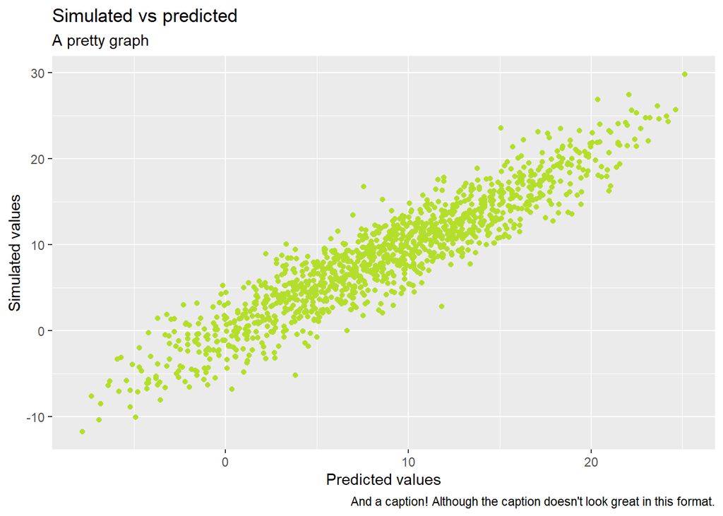

```r
library(ggplot2)
ggplot(grid_sim_1) +
 aes(x = yhat, y = sim) +
 geom_point(size = 1.44, colour = "#b4de2c") +
 labs(x = "Predicted values", y = "Simulated values", title = "Simulated vs predicted", subtitle = "A pretty graph", caption = "And a caption! Although the caption doesn't look great in this format.")
```

## Logistic fits

### Predict maturity

#### Fit a model

Here we’ll try to fit a model to predict the probability of an abalone being mature or not based on information we fit find in the fossil record. We’ll use ring number and shell weight.

Remember how our predicted vs observed graph looked for `model.fit`? It looked like we may want to consider grouping abalones into old and young categories. Let’s do that here, and also create an alternative `mature` column that takes on numeric values rather than factor levels (`gam` will need this).

```r
data3 <- data2%>%
  mutate(ring_cat=as.factor(ifelse(rings>=10,"10+","young")))%>%
  mutate(mature_int=ifelse(mature=="I",0,1))
data3$ring_cat<- relevel(data3$ring_cat, ref="young")
data3$mature<- relevel(data3$mature, ref="I")

fit.log1 <- glm(mature ~ ring_cat*shell, data = data3, family = binomial())
```

Great!

#### Check linearity

Remember that we need to make sure that the relationship between the logodds and our continuous predictor variable is linear. Let’s use `gam` to do that.

I’m not going to cover the `gam` function in detail yet. Here’s the code for now.

```r
library(mgcv)
```

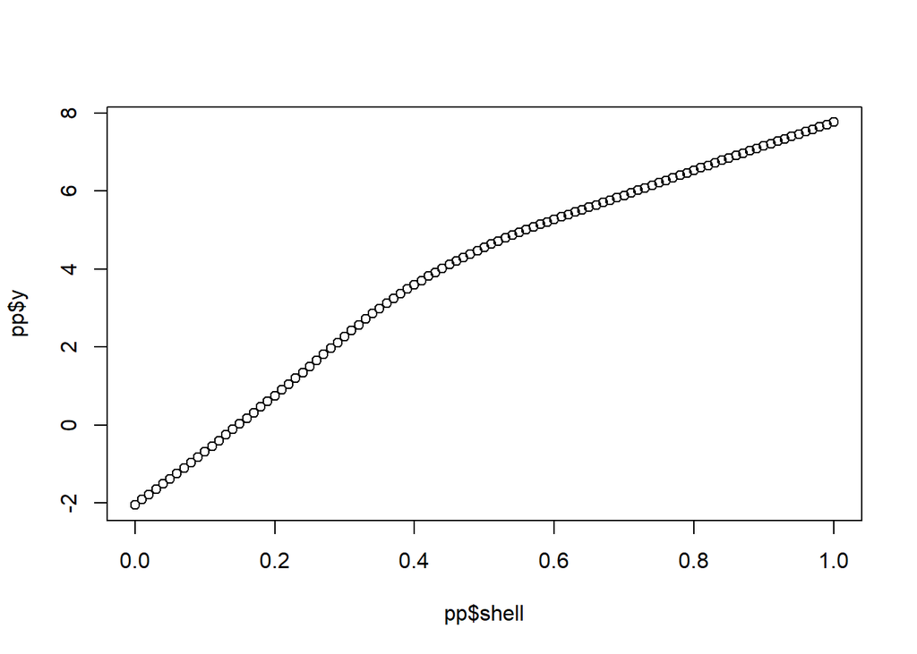

```r
gam1 <- gam(mature_int~s(shell),family="binomial",data=data3)

# plot(mature~shell, data=data3)
pp <- expand.grid(shell=seq(0,1,length=101),ring_cat=as.factor(c("young","10+")))
pp$y <- predict(gam1,newdata=pp)
# with(pp,lines(data3$shell,data3$mature))

plot(pp$shell,pp$y)
```

Looks like there’s a slight bend. Maybe we should consider adding a quadratic term for `shell`.

```r
fit.log2 <- glm(mature ~ ring_cat*shell + I(shell^2), data = data3, family = binomial())

AIC(fit.log1)
```

```
## [1] 3484.429
```

```r
AIC(fit.log2)
```

```
## [1] 3465.826
```

Looks like the addition of the quadratic term helps.

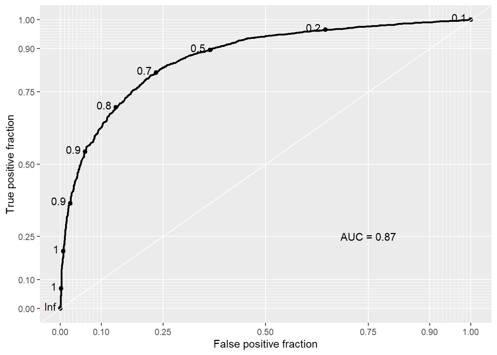

```r
library(plotROC)
pred1 <- cbind(data3,predict(fit.log1,type="response"))
names(pred1)[15] <- "pred"

basicplot <- ggplot(pred1, aes(d = mature_int, m = pred)) + geom_roc()+
  style_roc(theme=theme_grey)
basicplot <-  basicplot + annotate("text", x=0.75, y=0.25, label=paste("AUC =", round(calc_auc(basicplot)$AUC,2)))
basicplot
```

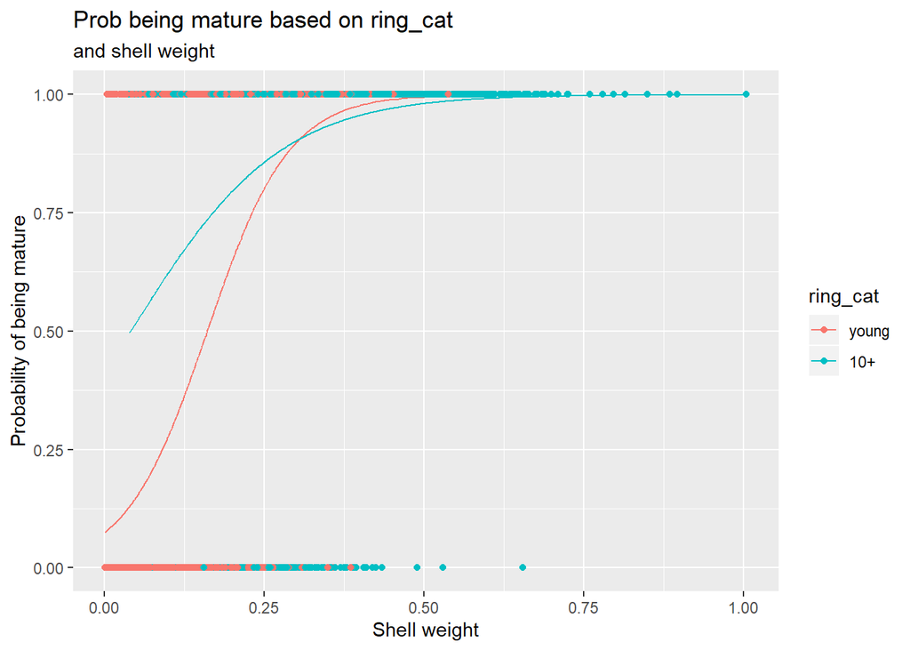

```r
plot <- ggplot(pred1, aes(x=shell,y=pred,group=ring_cat,color=ring_cat))
plot <- plot+geom_line()
plot <- plot+geom_point(aes(x=shell,y=mature_int))
plot=plot+labs(x = "Shell weight",
               y = "Probability of being mature",
               title = "Prob being mature based on ring_cat",
               subtitle = "and shell weight")
plot
```

#### Predictions and simulations from a logistic fit

Let’s use the simpler model `fit.log1` for this example. Note that we’re predicting the probability that an abalone is mature. Note also that `ring_cat10+` is not the reference level.

Let’s predict the probability that an abalone is mature given that it has 12 rings and a shell weight of 0.3.

Let’s make a function that generates probabilities from log-odds. This is just algebra.

```r
# This function that we save as "invlogit" will convert odds to probabilities
invlogit <- function(odds){
  exp(odds)/(1+exp(odds))
}
```

**Straight from the output**

```r
ya1 <- -2.5286 + 1*(2.1715) + 0.3*(15.6604) + 1*0.3*(-7.0929)
ya1
```

```
## [1] 2.21315
```

```r
invlogit(ya1)
```

```
## [1] 0.9014242
```

**Use the `predict()` function with the new data argument**

```r
new_x <- data.frame(shell=0.3,
                    ring_cat="10+")
ya2 <- predict(object = fit.log1, newdata=new_x)
ya2
```

```
##        1
## 2.213113
```

```r
invlogit(ya2)
```

```
##         1
## 0.9014209
```

**Using linear algebra**

```r
# When using the linear algebra method make sure to include a leading '1' for the intercept coeficient
vec_x <- as.matrix(c(1, 1, 0.3, 0.3*1))
b <- as.matrix(coef(fit.log1),ncol=1)

ya3 <- t(vec_x)%*%b
ya3
```

```
##          [,1]
## [1,] 2.213113
```

```r
invlogit(ya3)
```

```
##           [,1]
## [1,] 0.9014209
```

And what happens if the ring number is 5 instead? Notice that some of the terms just drop out due to the dummy variable coding.

**Straight from the output**

```r
ya4 <- -2.5286 + 0*(2.1715) + 0.3*(15.6604) + 0*0.3*(-7.0929)
ya4
```

```
## [1] 2.16952
```

```r
invlogit(ya4)
```

```
## [1] 0.8974788
```

**Use the `predict()` function with the new data argument**

```r
new_x <- data.frame(shell=0.3,
                    ring_cat="young")
ya5 <- predict(object = fit.log1, newdata=new_x)
ya5
```

```
##        1
## 2.169483
```

```r
invlogit(ya5)
```

```
##         1
## 0.8974754
```

**Using linear algebra**

```r
# When using the linear algebra method make sure to include a leading '1' for the intercept coeficient
vec_x <- as.matrix(c(1, 0, 0.3, 0.3*0))
b <- as.matrix(coef(fit.log1),ncol=1)

ya6 <- t(vec_x)%*%b
ya6
```

```
##          [,1]
## [1,] 2.169483
```

```r
invlogit(ya6)
```

```
##           [,1]
## [1,] 0.8974754
```

If we want to simulate 10 observations from one of these predicted values we just need to use the `rbinom()` function. (There’s a reason we set the `family = binom`). `size` is going to be equal to 1 since we’re simulating binary data (just 0’s and 1’s).

```r
rbinom(n = 10, size = 1, prob = invlogit(ya6))
```

```
##  [1] 0 1 1 0 1 1 1 1 1 1
```

That’s it!

### Predict Ring number

This section isn’t testable, so my notes will be *very* sparse.

Instead of using a linear or poisson model to predict ring number we could try using a multinomial or ordinal model (essentially multiple logistic regressions).

```r
newdat <- data.frame(
  curt_vol = data2$curt_vol,
  whole = data2$whole,
  mature = data2$mature)

newdata2 <- data2%>%
  mutate(rings=as.ordered(rings))

library(MASS)
library(nnet)
multi_1=multinom(rings~curt_vol + whole + mature , data = newdata2)
ord_1=polr(rings~curt_vol + whole + mature , data = newdata2)
```

```r
check_counts <- newdata2%>%
  group_by(rings)%>%
  summarise(count=n())
check_counts <- as.data.frame(check_counts)
```

```r
newdata3 <- data2%>%
  mutate(new_cat=as.factor(ifelse(rings<=5,5,ifelse(rings>=16,16,rings))))
newdata3$new_cat = factor(newdata3$new_cat,levels(newdata3$new_cat),ordered=T)
```

```r
check_counts2 <- newdata3%>%
  group_by(new_cat)%>%
  summarise(count=n())
check_counts2 <- as.data.frame(check_counts2)
```

```r
multi_2=multinom(new_cat~curt_vol + whole + mature , data = newdata3)
ord_2=polr(new_cat~curt_vol + whole + mature , data = newdata3)
```

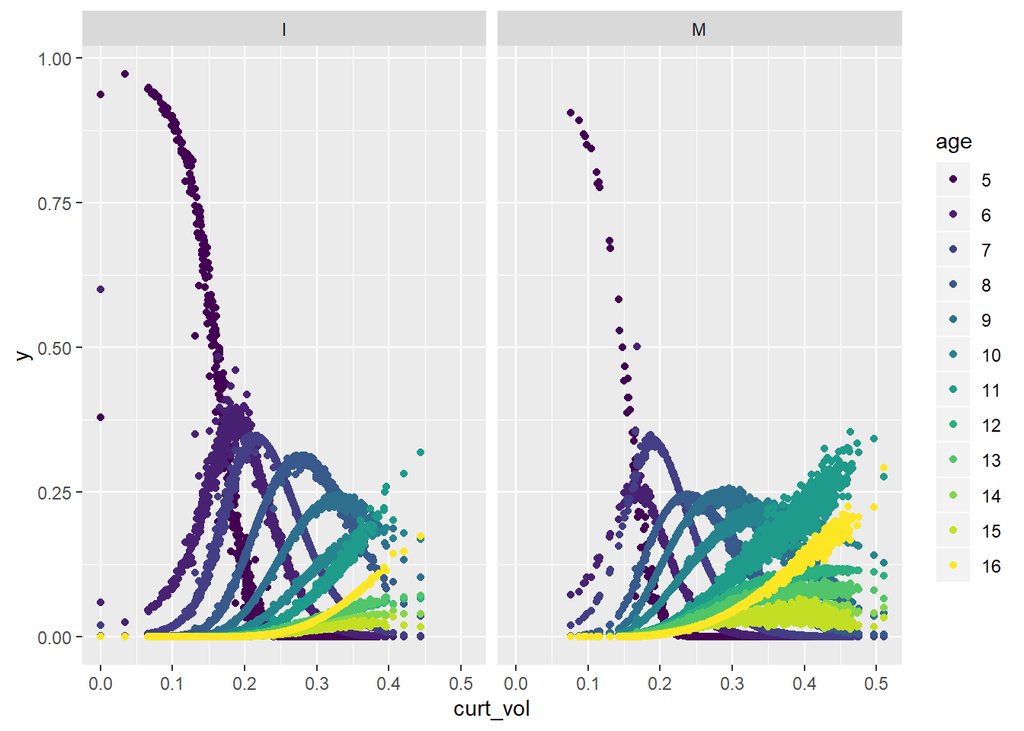

```r
p1=predict(multi_2, type="probs")
pred.m <- cbind(newdat, predict(multi_2, newdat, type = "probs"))

pred.m.1 <- pred.m %>%
  gather(key=age,  value=y,  "5":"16")
library(plyr)

pred.m.1$age=as.ordered(pred.m.1$age)
pred.m.1$age = factor(pred.m.1$age,levels(pred.m.1$age)[c(8:12,1:7)])
# newdata$age=as.numeric(as.character(newdata$age))

plot1=ggplot(pred.m.1, aes(x=curt_vol,y=y,color=age))
plot1=plot1+geom_point()
plot1=plot1 + facet_wrap(~mature)
plot1
```

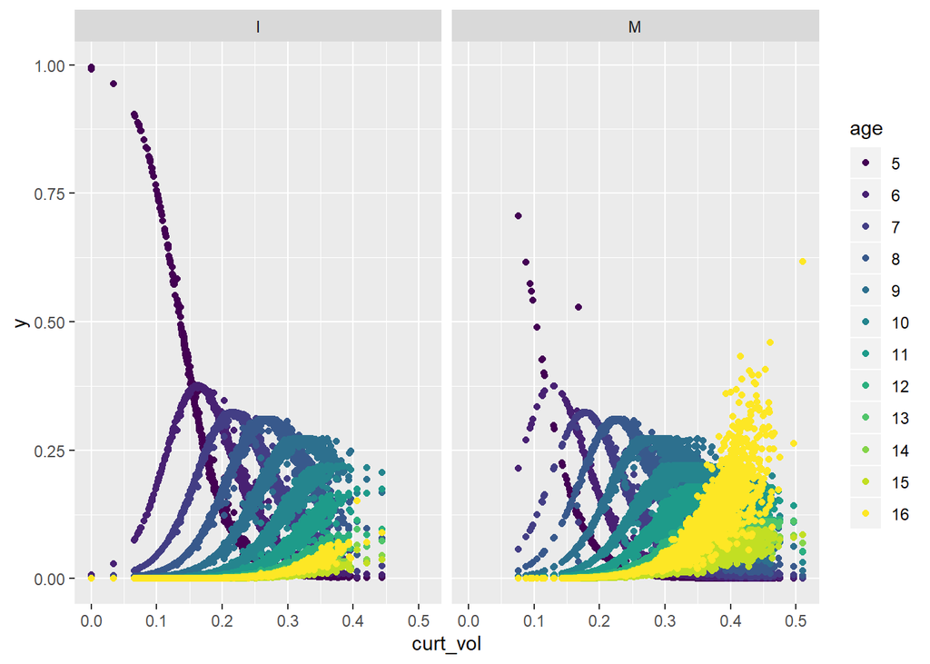

```r
p2=predict(ord_2, type="probs")
pred.o <- cbind(newdat, predict(ord_2, newdat, type = "probs"))

pred.o.1 <- pred.o %>%
  gather(key=age,  value=y,  "5":"16")
library(plyr)

pred.o.1$age=as.ordered(pred.o.1$age)
pred.o.1$age = factor(pred.o.1$age,levels(pred.o.1$age)[c(8:12,1:7)])
# newdata$age=as.numeric(as.character(newdata$age))

plot2=ggplot(pred.o.1, aes(x=curt_vol,y=y,color=age))
plot2=plot2+geom_point()
plot2=plot2 + facet_wrap(~mature)
plot2
```

## Creating logit/inverse logit functions

For interest.

```r
# This function that we save as "logit" will convert probabilities to odds

logit <- function(probs) {
    log(probs/(1-probs))
}

# This function that we save as "invlogit" will convert odds to probabilities
invlogit <- function(odds){
  exp(odds)/(1+exp(odds))
}
```